# Lesson 1: Visualizing data with *ggplot2*

### 4.2.2 Decorating our plots with more data

Now that we have a basic scatterplot in hand, we can try to gain deeper insights into our data by incorporating more information into our plot. Our current scatterplot shows a positive relationship between flipper length and body mass. We know the penguin data frame contains measurements from three different penguin species. Let’s map species to the color aesthetic to see how this trend looks across all three species.

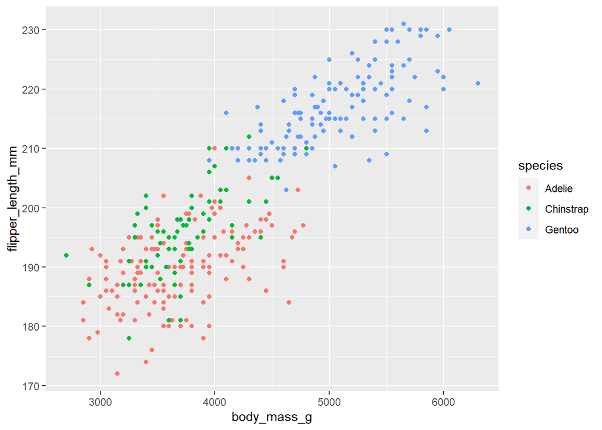

```r
ggplot(data = penguins,
       mapping = aes(x = body_mass_g, y = flipper_length_mm,
                     color = species)) +
    geom_point()
```

Not only did *ggplot2* automatically assign a different color to each penguin species, it also added a legend to the graph. That means this same block of code can work for a penguin data frame that contains data from one, two, or ten species of penguin.

To get a clearer picture of the trend between flipper length and body mass, we’re no going to add a regression line to the plot. We’ll do this with the `geom_smooth()` function. We’ll use the `method = "lm"` argument to specify we want to plot the line we get from fitting our data with a **l**inear **m**odel.

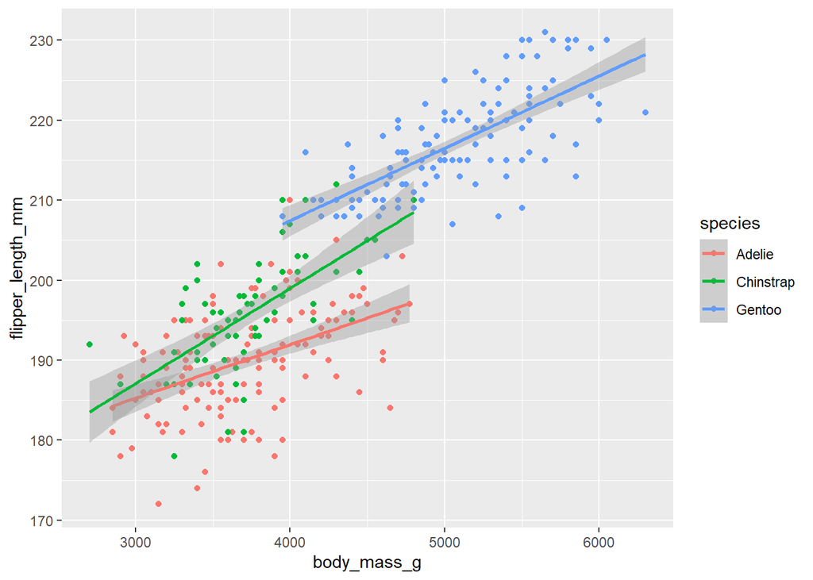

```r
ggplot(data = penguins,
       mapping = aes(x = body_mass_g, y = flipper_length_mm,
                     color = species)) +
    geom_point() +
    geom_smooth(method = "lm")
```

It looks like `geom_smooth()` fit separate linear models for each penguin species and plotted the lines using the same colors as the points. While this is a useful feature (we’ll make use of this below), we want to fit all of the data with a single linear model. When we define aesthetic mappings in the `ggplot()` function, they apply to *all* `geom_` functions in that plot. By mapping species to color, we told `geom_smooth()` we want it to color the smoothed line by species, which means it needs to fit a separate line for each species. To solve this problem we can specify an aesthetic mapping within a specific `geom_` function. Let’s try moving the species to color mapping to `geom_point()` and `geom_smooth()`. Which option still colors the points by species, but fits all of the data with a single linear model?

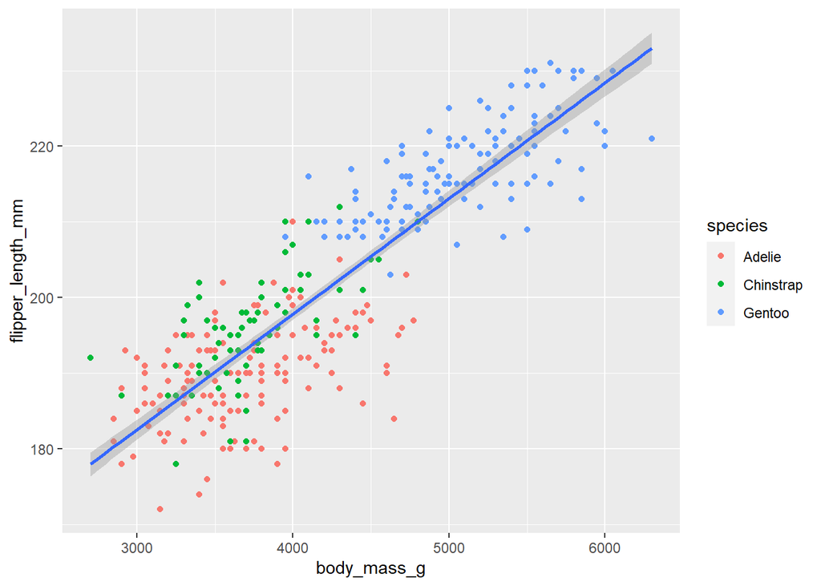

```r
ggplot(data = penguins,
       mapping = aes(x = body_mass_g, y = flipper_length_mm)) +
    geom_point(mapping = aes(color = species)) +
    geom_smooth(method = "lm")
```

Now that we’ve sorted out the trend line, let’s return to how we’re plotting the points. The colors improve the readability of this graph, but could pose a problem if this figure is rendered in black and white, or if a reader has certain types of colorblindness. One solution is to map the points from different penguin species to different shapes. Try adding an aesthetic mapping of `shape` to species.

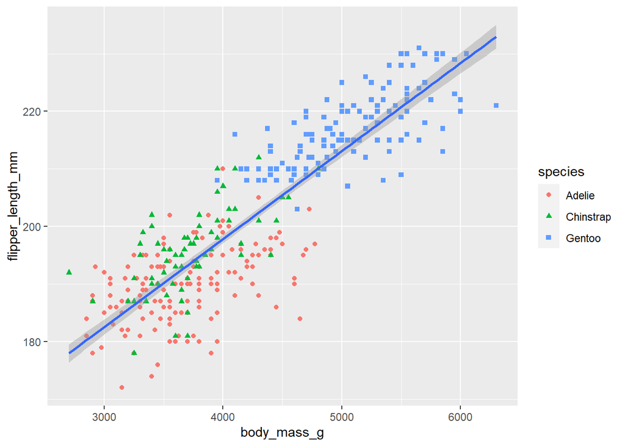

```r
ggplot(data = penguins,
       mapping = aes(x = body_mass_g, y = flipper_length_mm)) +
    geom_point(mapping = aes(color = species, shape = species)) +
    geom_smooth(method = "lm")
```

Note that the legend automatically updates to reflect the new shape mapping.

The are many more aesthetics beyond shape and color. The documentation for `geom_` functions contains a special section listing the aesthetic mappings supported by that geom. Look up the help page for “geom_point” and find the list of supported aesthetics.

We’re almost done recreating the figure we saw at the beginning of this section. The axis labels our version of the figure are not as clean, and we’re still missing the plot title and subtitle. Collectively, these attributes are known as the graph’s “labels”, and we can modify them using the `labs()` function.

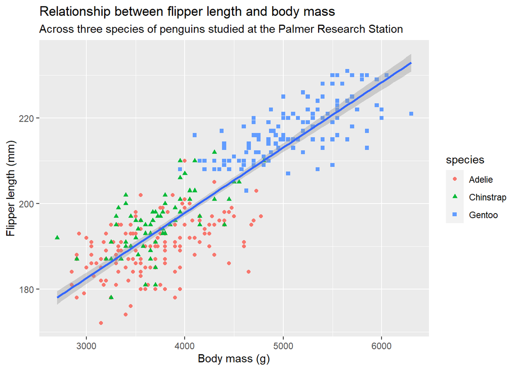

```r
ggplot(data = penguins,
       mapping = aes(x = body_mass_g, y = flipper_length_mm)) +
    geom_point(mapping = aes(color = species, shape = species)) +
    geom_smooth(method = "lm") +
    labs(title = "Relationship between flipper length and body mass",
         subtitle = "Across three species of penguins studied at the Palmer Research Station",
         x = "Body mass (g)",
         y = "Flipper length (mm)")
```

Lastly, we’ll change the color scheme to a different palette from the default. The *ggplot2* package includes a few additional color palettes we can apply to our plot using `scale_color_` functions. For now, we’ll select a palette from the ColorBrewer collection that is good for representing qualitative data and is more colorblind safe than the default palette.

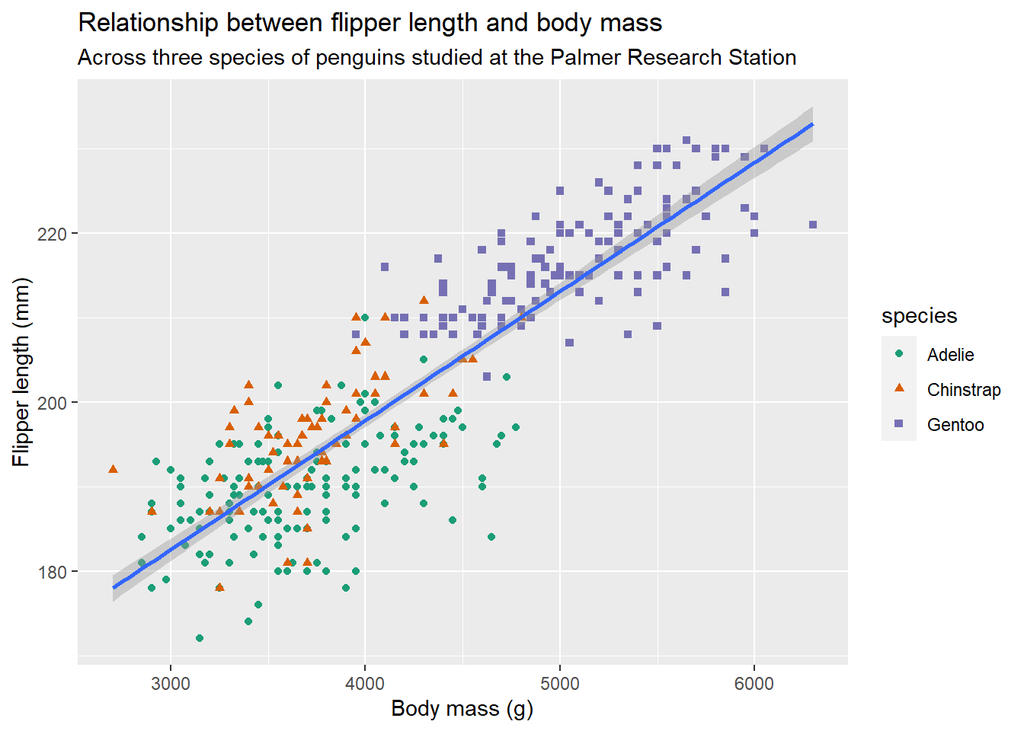

```r
ggplot(data = penguins,
       mapping = aes(x = body_mass_g, y = flipper_length_mm)) +
    geom_point(mapping = aes(color = species, shape = species)) +
    geom_smooth(method = "lm") +
    labs(title = "Relationship between flipper length and body mass",
         subtitle = "Across three species of penguins studied at the Palmer Research Station",
         x = "Body mass (g)",
         y = "Flipper length (mm)") +
    scale_color_brewer(palette = "Dark2")
```

For now, we’re not going to worry about the specifics of the ColorBrewer collection of palettes (though feel free to examine the documentation for the `scale_color_brewer()` function). But we can see that we can further adjust how *ggplot2* displays our data using the `scale_` family of functions.

With that last tweak, we’ve successfully recreated the figure we saw above.

### 4.2.3 Creating our own scatterplot

Now we’re going to put everything we just learned into practice. Using the `penguins` data and the *ggplot2* functions, we’re going to create a scatterplot of bill depth vs bill length. We can view the contents of `penguins` data frame directly, or consult the documentation to find the names of the columns that contain this information. Again, we’ll add a regression line that we fit using all of the data.

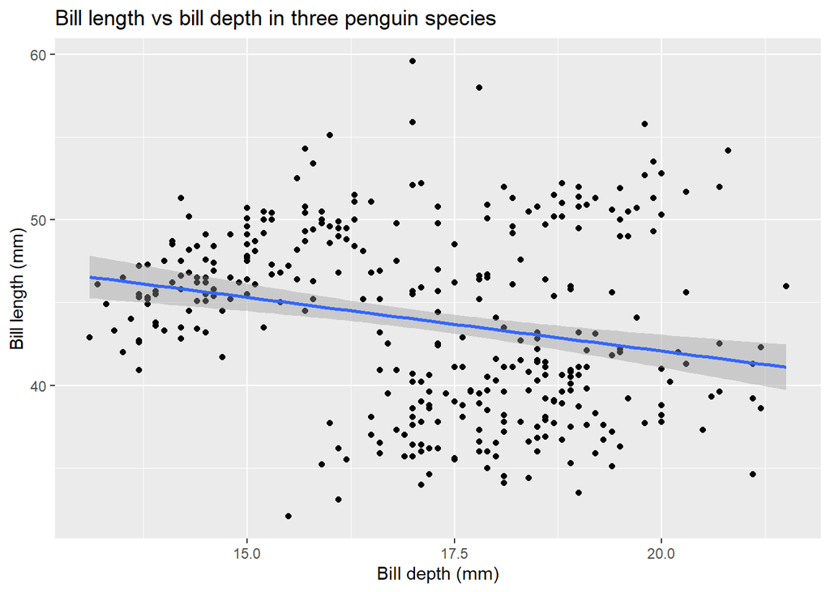

```r
ggplot(data = penguins,
       mapping = aes(x = bill_depth_mm, y = bill_length_mm)) +
    geom_point() +
    geom_smooth(method = 'lm') +
    labs(title = "Bill length vs bill depth in three penguin species",
         x = "Bill depth (mm)",
         y = "Bill length (mm)")
```

Looking at the graph we created, what does it suggest about a relationship between bill depth and bill length? How might species affect this? How does the graph change if we fit separate regression lines within each species?

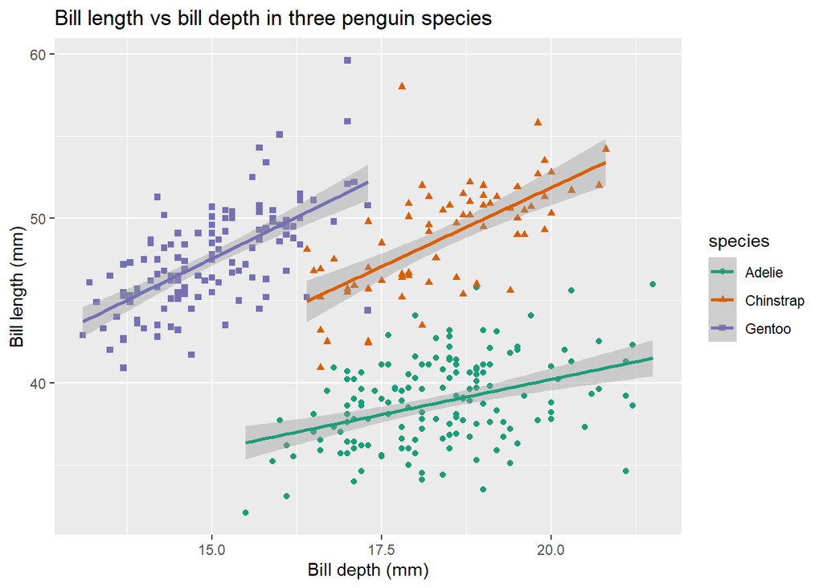

```r
ggplot(data = penguins,
       mapping = aes(x = bill_depth_mm, y = bill_length_mm, color = species)) +
    geom_point(mapping = aes(shape = species)) +
    geom_smooth(method = 'lm') +
    labs(title = "Bill length vs bill depth in three penguin species",
         x = "Bill depth (mm)",
         y = "Bill length (mm)") +
    scale_color_brewer(palette = "Dark2")
```

The difference between these two graphs is an example of [Simpson’s paradox](https://en.wikipedia.org/wiki/Simpson%27s_paradox). Briefly, this is a phenomenon where a trend between two variables at the population level disappears, emerges, or reverses when we divide the population into groups. We were able to observe these changes by experimenting with the way we visualized the penguin data.

We’re only just scratching the surface of what we can do with *ggplot2*, but we’ve used it to rapidly visualize the penguin data and generate some interesting observations. In the next lesson, we will explore some of these observations further by working directly with the data to calculate summary statistics.

# 5 R session information

Just as it’s good practice for us to list all of the packages we load at the top of our code, it’s equally important to report the version number for R and the package versions we used at the end of our code. This will make it much easier to reproduce our results in the future. By running the `sessionInfo()` function at the end of our code, we capture any changes to the environment that happened in the body of our code (e.g some function silently load additional packages when you run them).

[session information not shown]

Back to top